# Text Mining Basics

2021-09-30

## Methods you will encounter

In this first module, we will investigate the basics of text mining. You will learn about the following concepts:

- What are corpus, types, tokens, sentences?
- What is a readability score?
- Many text mining/NLP methods need a numeric representation of the text. The starting point for that is a document frequency matrix.
- You will also learn about how to (pairwise) compare texts. We will look at one score, namely cosine similarity.
- A simple way to analyze whether specific information is available in a text is the keywords in context analysis.

## R and quanteda

- In this tutorial, we will mostly use one package which is called quanteda.
- quanteda is an R package for managing and analyzing textual data.
- The package is designed for applying natural language processing to texts.
- It is heavily used by political and social scientists.

## Context: Political Speech and Divisiveness

“Most citizens want a secure country, safe neighborhoods and good schools. These issues do get discussed, of course, but a disproportionate amount of attention goes to issues like abortion, medical marijuana, and other narrow issues that simply do not motivate the great majority.” Fiorina, Abrams, and Pope (2005), p. 202).

## Context: Political Speech and Divisiveness

- Ash, Morelli, and Van Weelden (2017) use floor speeches by Members of the U.S. Congress and find that U.S. Senators spend more time on divisive issues when they are up for election.
- In this tutorial, we investigate divisiveness of political speech via Plenarprotokolle from the German Bundestag.

## Data

To increase computational speed, the data consists only of 5 protocols from the [German Bundestag](https://www.bundestag.de/services/opendata). I downloaded the .xml files and transformed them to using a Python script to .txt (`xml_to_txt.py`) beforehand.

```r
temp = list.files(path="data/prtkll/19WP",pattern="*.txt")
df = do.call(rbind, lapply(temp, function(x) readtext(paste("data/prtkll/19WP/",x,sep=""))))
```

🤓: There are additional protocol files in the `data/prtkll/19WP/unused` folder. You can adapt the data directory to try out different data sets.

## Types, tokens, sentences

[Stanford Encyclopedia of Philosophy](https://plato.stanford.edu/entries/types-tokens/)

- From “Sacred Emily,” by Gertrude Stein: **Rose is a rose is a rose is a rose.**
- Includes three different types.
- Includes ten different tokens.

```r
corpus.both<-corpus(df)
s<-summary(corpus.both)
```

On average, each document consists of 1.32572^{4} types, 1.426^{5} tokens, and 7012.8 sentences.

## Readability Scores

Readability is the ease with which a reader can understand a written text. We will look at one particular score, namely the Flesch’s Reading Ease (FRE) Score (Flesch 1948).

### Characteristics

- Uses a combination of syllables and sentence length to indicate the complexity of speech
- Optimized for English
- The higher the FRE value, the easier the text

### Usage

- It can be interesting to calculate the readability of newspaper articles, books, Wikipedia articles.
- Grammarly uses it also to provide recommendations for the writer.
- An interesting political science application is delivered by Spirling (2016). The authors investigate the impact of the Second Reform Act on the linguistic complexity of speeches made by members of parliament in Great Britain.

### Flesch’s Reading Ease Score

\[ N_{sy} = \text{number of syllables} \\ N_w = \text{number of words} \\ N_s = \text{number of sentences} \\ \text{Average Sentence Length (ASL)} = \frac{N_w}{N_s} \\ 206.835−(1.015× ASL)−(84.6×\frac{N_{sy}}{N_w}) \]

```r
readability<-textstat_readability(corpus.both, "Flesch")
```

The lowest readability score is 28.66, the highest is 37.31.

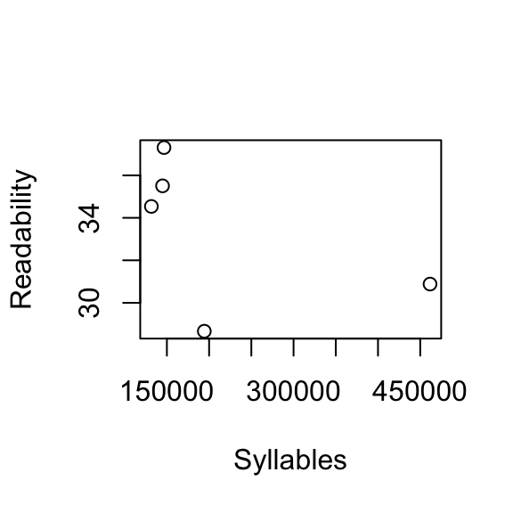

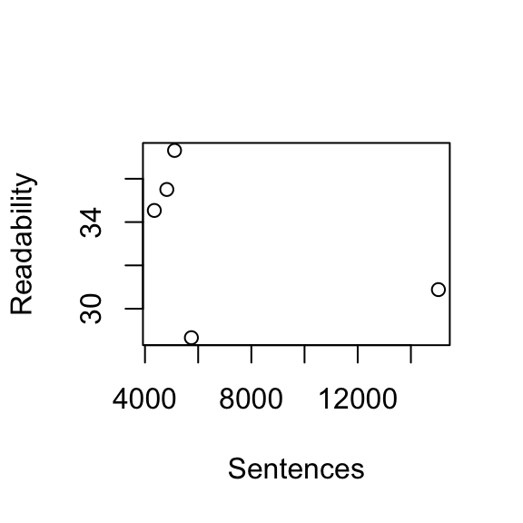

## Document Frequency Matrix

- A document-feature matrix (dfm) shows the documents in the rows, the features in the columns.
- It can be interpreted as the implementation of the bag-of-words concept (more about that later).
- It often builds the basis for further NLP methods, such as classification.
- The dfm, sorted in a decreasing (increasing) way, shows the most (least) common tokens.
- The sparsity of a dfm denotes the proportion of \(0\) in the matrix. Dfms can become quite large and sparse.

```r
both.dfm<-dfm(tokens(corpus.both),
              remove = stopwords("german"),
              remove_punct= TRUE)
head(dfm_sort(both.dfm, decreasing = TRUE))
```

```
## Document-feature matrix of: 5 documents, 35,665 features (65.26% sparse) and 0 docvars.
##                 features
## docs             dass   dr   19  cdu beifall  csu  spd  afd  fdp grünen
##   2021-06-23.txt  547  543  889  409     373  399  399  470  465    464
##   2021-06-24.txt 1374 1746 1559 1255     986 1128 1021 1090 1049   1050
##   2021-06-25.txt  547  272  355  527     582  496  444  380  387    359
##   2021-08-25.txt  595  586   97  416     449  396  313  296  255    271
##   2021-09-07.txt  556  410  113  354     468  339  391  242  319    261
## [ reached max_nfeat ... 35,655 more features ]
```

## Cosine Similarity

- The cosine similarity \(k\) is the cosine of the angle between vectors.
- It quantifies the similarity between two or more vectors.
- The more similar the frequencies, the smaller the angle between the vectors.
- \(k\) close to \(1\) indicates high similarity.
- If \(x\) and \(y\) are row vectors, their cosine similarity \(k\) is defined as: \[ k(x,y))=\frac{xy^T}{||x|| ||y||} \]

### Cosine Similarity Applied

- A reference document is selected by chance.
- Usually, we are interested in document similarities for a corpus of documents.
- Therefore, scaling methods (which we will encounter in module 3) are preferred over pairwise similarity measures like cosine similarity.

```r
textstat_simil(both.dfm, method = "cosine", margin = "documents")
```

```
## textstat_simil object; method = "cosine"
##                2021-06-23.txt 2021-06-24.txt 2021-06-25.txt 2021-08-25.txt
## 2021-06-23.txt          1.000          0.922          0.849          0.758
## 2021-06-24.txt          0.922          1.000          0.902          0.830
## 2021-06-25.txt          0.849          0.902          1.000          0.867
## 2021-08-25.txt          0.758          0.830          0.867          1.000
## 2021-09-07.txt          0.746          0.824          0.870          0.905
##                2021-09-07.txt
## 2021-06-23.txt          0.746
## 2021-06-24.txt          0.824
## 2021-06-25.txt          0.870
## 2021-08-25.txt          0.905
## 2021-09-07.txt          1.000
```

## Dictionary, summary statistics and keywords in context

## Dictionary to capture divisiveness

The dictionary is based on Ash, Morelli, and Van Weelden (2017 appendix, p.22). It includes 19 words that denote divisive issues as well as 19 words and bigrams that denote common-values issues.

```r
mydict <- dictionary(list(divisive = c("Stammzell*","Haushaltsgleichgewicht*","?lf*","Verm?genssteuer*",
"Krankenversicherung*","Stammzellenforschung*","Staatsverschuldung*",
"Bruttoinlandsprodukt*","Einkommenssteuer*","Steuererh?hung*",
"Drogenkontrolle*","fossile Brennstoffe","Abtreibung*","
Kleinunternehmer*","Inflation*","verschreibungspflichtig*","Sozialversicherung*",
"Mindestlohn*","Atomkrieg*"),
common_value = c("Finanzen*","Chemiewaffen*","?ffentlicher Dienst*","Staatsdiener*","Verteidigung*","
Menschenrecht*","Demokratie*","Verkehrsministeri*","st?dtische Finanz*","Staatshaushalt*","innere Sicherheit",
"medizinische Versorgung*","internationale Finanzverwaltung*",
"Strafverfolgung*","Gesetzesvollzug*","nationale Sicherheit*","privat* Sektor*",
"erneuerbare Energi*","Forschung und Entwicklung*")))
```

## Summary Statistics

```r
head(textstat_frequency(dfm(corpus.both, stem=TRUE, select = mydict$divisive)))
```

```
##                feature frequency rank docfreq group
## 1          mindestlohn        23    1       3   all
## 2               inflat         8    2       2   all
## 3     steuererhöhungen         7    3       3   all
## 4 bruttoinlandsprodukt         6    4       3   all
## 5                  elf         5    5       5   all
## 6   staatsverschuldung         5    5       2   all
```

```r
head(textstat_frequency(dfm(corpus.both, stem =TRUE, select = mydict$common_value)))
```

```
##                      feature frequency rank docfreq group
## 1                  demokrati       133    1       5   all
## 2              menschenrecht        94    2       4   all
## 3                   finanzen        25    3       5   all
## 4    verteidigungsministerin        18    4       4   all
## 5               verteidigung        17    5       4   all
## 6 menschenrechtsverletzungen        14    6       4   all
```

## Category matches per document

```r
corpus.both.dfm<-dfm(corpus.both, dictionary = mydict) #category matches per text
corpus.both.dfm
```

```
## Document-feature matrix of: 5 documents, 2 features (0.00% sparse) and 0 docvars.
##                 features
## docs             divisive common_value
##   2021-06-23.txt        5           95
##   2021-06-24.txt       23          123
##   2021-06-25.txt       22          178
##   2021-08-25.txt        2           65
##   2021-09-07.txt       28           33
```

## Log-ratio and document length

🤓: Find out whether logratio of divisive to common-value terms is independent of the document length (measured by tokens).

```r
logratio<-c()
for(i in 1:corpus.both.dfm@Dim[1]){
 logratio[i]<-log(as.vector(corpus.both.dfm[i,2])/ as.vector(corpus.both.dfm[i,1]))
}

s$Tokens
```

```
## [1] 127537 300576 100577  96650  87660
```

## Key words in context

- Let’s have a look at keywords in context.
- We choose the three common-value tokens with the highest number of matches as keywords.
- We print the context as bigrams.

```
## [1] "demokrati*"
## [1] "zumutungen_namen"          "zusammen_mitgestalten"
## [3] "zusammenarbeit_wirklich"   "zusammenarbeiten_teilung"
## [5] "zusammenleben_unabdingbar" "zusatzpunkt_7"
## [1] "menschenrecht*"
## [1] "zentrum_iranpolitik"           "zeugen_erodierenden"
## [3] "zuge_sportgroßveranstaltungen" "zuständen_wirklich"
## [5] "zwei_legislaturperioden"       "zweites_stichwort"
## [1] "finanzen*"
## [1] "nein_gibt"
## [2] "nordrhein-westfalen_bundesministerium"
## [3] "olaf_scholz"
## [4] "rekurrieren_herr"
## [5] "scholz_bundesminister"
## [6] "wirtschaft_all"
```

## It’s your turn! 👩‍💻 ~10’

## References

Ash, Elliott, Massimo Morelli, and Richard Van Weelden. 2017. “ Elections and divisiveness: Theory and evidence.” *The Journal of Politics* 79 (4): 1268–85.

Fiorina, Morris P, Samuel J Abrams, and Jeremy C Pope. 2005. “ Culture war.” *The Myth of a Polarized America* 3.

Flesch, Rudolph. 1948. “ A new readability yardstick.” *Journal of Applied Psychology* 32 (3): 221.

Spirling, Arthur. 2016. “ Democratization and linguistic complexity: The effect of franchise extension on parliamentary discourse, 1832–1915.” *The Journal of Politics* 78 (1): 120–36.